# Quantifying volume transports along pathways crossing a section in the VIKING20X model by Lagrangian particle tracking.

This fundamentally relies on the idea that we can associate a volume transport with a particle, and that this volume transport remains constant (or changes only slowly) as we follow the particle. So like a streamtube.

This assumption is possibly only strictly valid in the absence of mixing, and possibly only for the mean flow. Never mind though, we'll press on and consider the implications further down the line.

First, consider how to sample the velocity field with particles to accurately estimate the transport across a section, and enable us to track the volume transport upstream and downstream. There are a couple of obvious options:

1. Randomly sample the section with particles at time t. Each particle, p, then has an associated volume transport, $V_p$: $$ V_p = \frac{A}{N}\boldsymbol{u_p \cdot n_p}, $$ where $A$ is section area, $N$ the number of particles, and $\boldsymbol{u_p \cdot n_p}$ the velocity normal to the section at point $p$.
2. Sample with particles with local release density proportional to the local velocity normal to the section. Every particle is then associated with the same volume transport.

Method 1 is easier to set up so I'll look at that first. Method 2 might be more efficient (better results with fewer particles).

### Method 1

- Select a section (Greenland - Iceland - Shetland - Scotland)
- Calculate VIKING20X model volume transport across the section accurately
- Estimate volume transport based on N randomly released particles

## Define a section and find grid points along the section

```python
vertices_lat = np.array([68.74,65.8,64.78,65,62.2,60.33,58.99,58.58])
vertices_lon = np.array([-28.73,-23,-18.4,-14,-7.0,-1.3,-3.06,-3.21])
ll_points = np.vstack((vertices_lat, vertices_lon)).T
ll_points
```

```
array([[ 68.74, -28.73],
       [ 65.8 , -23.  ],
       [ 64.78, -18.4 ],
       [ 65.  , -14.  ],
       [ 62.2 ,  -7.  ],
       [ 60.33,  -1.3 ],
       [ 58.99,  -3.06],
       [ 58.58,  -3.21]])
```

```python
print(vertices_ji)
```

```
[[2476 1410]
 [2371 1494]
 [2338 1567]
 [2352 1636]
 [2271 1762]
 [2225 1870]
 [2174 1848]
 [2160 1848]]
```

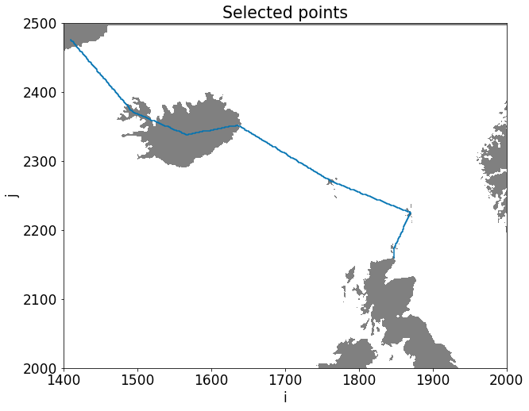

```python
plot_selected_points()
```

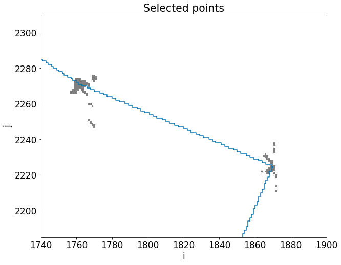

```python
plot_selected_points()
```

## Plot mean velocity normal to section.

### Northward, into the page, is positive.

### Greenland on the left, Scotland on the right.

Section is a zigzag line following grid cell boundaries, so normal to section is either u (on N-S boundaries) or v (on E-W boundaries). This is where the 'vertical' stripes on the plot come from, they are not structure in the velocity field.

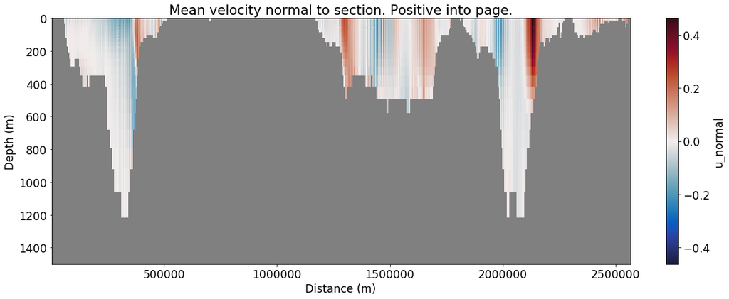

```python
plot_section()
```

## Monthly mean volume transport

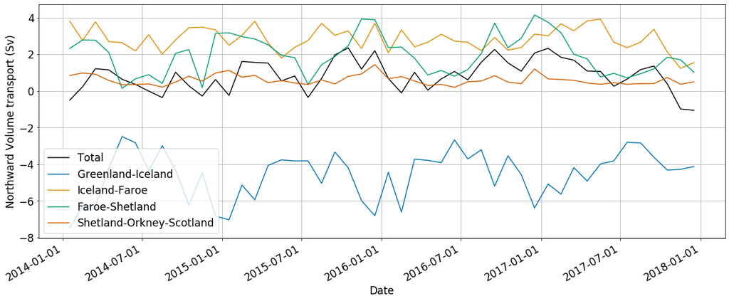

```python
plot_transport_timeseries()
```

## Transport estimates from particle releases for 2016

- These are estimates on the sections at particle release time, to test how many particles might be needed for reliable volume transport estimates.
- These use 4000 particles per sub-section.
- For Iceland-Faroe and Faroe-Shetland subsections.

Faroe-Shetland Channel particle release (December 2016).

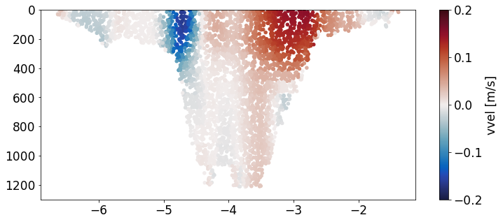

```python
plot_release_FSC()
```

Iceland-Faroe Ridge particle release (December 2016).

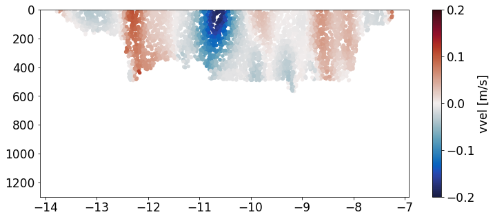

```python
plot_release_IFR()
```

### Plot accurate transports from model calculations against estimates from random particle samples.

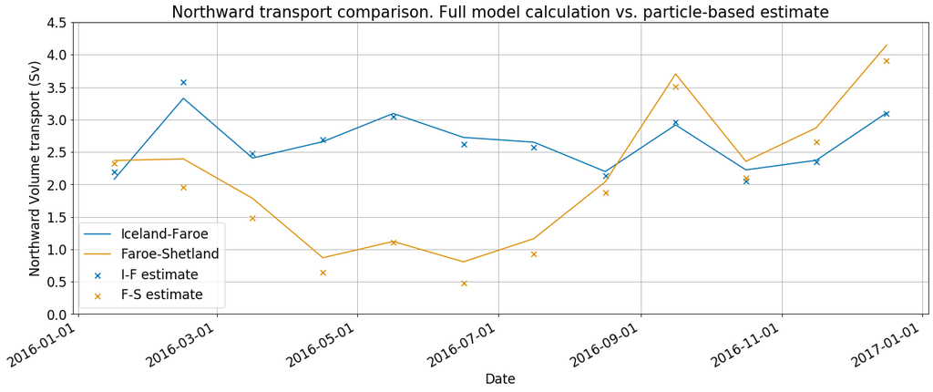

```python
plot_transport_comparison()
```

### **Conclusion:**

- Estimates are not bad with 4000 particles on each sub-section. Errors well below the monthly transport variability.

$$12500\, particles \times 12\, months \times 40\, years = 6000000\, particles$$

- There may be some systematic underestimate of total transport in Faroe-Shetland Channel.
- Random sample was taken from the same positions each time. This may explain the possible bias. Probably need to vary this (while keeping it reproducible).
- Probably under-sampling the strong narrow currents leads to the bias -- use more particles or release them more intelligently.